# POLISCI 9590 - Lab10: A review of the course

William Poirier

2025-12-03

## 1. Data Wrangling in R

- For today's lab, we return to the CES 2021 data.

```r
library(tidyverse)
library(rio)
library(uwo4419)

# Data
setwd(dirname(rstudioapi::getActiveDocumentContext()$path))
CES_raw <- import("2021 Canadian Election Study v2.0.dta")

## A function to replace -99 by NA
remove99 <- function(x){
  out <- ifelse(x==-99,NA,x)
  return(out)
}

## Cleaning
CES <- factorize(CES_raw) |>
  # Renaming variables
  rename(UUID=cps21_ResponseId,
         yob=cps21_yob,
         gender=cps21_genderid,
         prov=cps21_province,
         vote=pes21_votechoice2021,
         pplFeel_Americans=cps21_groups_therm_7,
         pplFeel_Francophones=cps21_groups_therm_3,
         pplFeel_LPC=cps21_party_rating_23,
         pplFeel_CPC=cps21_party_rating_24,
         pplFeel_NDP=cps21_party_rating_25,
         pplFeel_BQ=cps21_party_rating_26,
         pplFeel_GPC=cps21_party_rating_27,
         pplFeel_PPC=cps21_party_rating_29) |>
  # Making my selection
  select(UUID,yob,gender,prov,vote,
         pplFeel_Americans,pplFeel_Francophones,
         pplFeel_LPC,pplFeel_CPC,pplFeel_NDP,
         pplFeel_BQ,pplFeel_GPC,pplFeel_PPC) |>
  # Removing territories
  filter(!(prov %in% c("Northwest Territories","Nunavut","Yukon"))) |>
  mutate(age=2021-as.numeric(as.character(yob)),
         vt = case_when(
              vote == "Liberal Party" ~ "LPC",
              vote == "Conservative Party" ~ "CPC",
              vote == "ndp" ~ "NDP",
              vote == "Bloc Québécois" ~ "BQ",
              vote == "Green Party" ~ "GPC",
              vote == "People's Party" ~ "PPC",
              vote == "Another party (specify)" ~ "Other",
              vote %in% c("I spoiled my vote","Don't know / Prefer not to answer") ~ NA_character_
            ),
         prov=factor(prov,levels=c("British Columbia","Alberta","Saskatchewan","Manitoba",
                                   "Ontario","Quebec",
                                   "New Brunswick","Prince Edward Island","Nova Scotia",
                                   "Newfoundland and Labrador"))) |>
  mutate_at(vars(starts_with("pplFeel")),remove99) |>
  filter(gender %in% c("A man", "A woman")) |>
  mutate(gender=droplevels(gender))
```

- Using the data we just cleaned (`CES`):
  1. Compute the average score given to each party per province.
  2. Present these averages in a graph where the Y axis are the provinces and the X axis the averages.

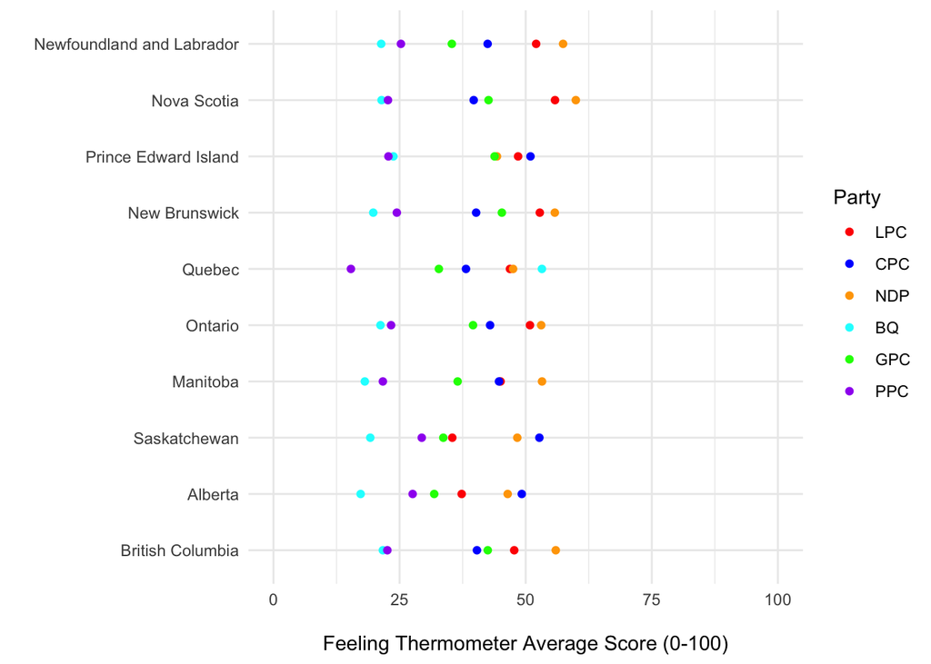

```r
CES |>
  select(-pplFeel_Americans,-pplFeel_Francophones) |>
  group_by(prov) |>
  summarise(across(starts_with("pplFeel_"),~mean(.x,na.rm=T))) |>
  ungroup() |>
  pivot_longer(-prov,names_pattern = "pplFeel_(.*)",names_to = "Party", values_to = "score") |>
  mutate(Party=factor(Party,levels=c("LPC","CPC","NDP","BQ","GPC","PPC"))) |>
  ggplot(aes(x=score,y=prov,color=Party))+
  geom_point() +
  scale_color_manual(values=c("red","blue","orange","cyan","green","purple"))+
  theme_minimal()+
  coord_cartesian(xlim=c(0,100))+
  labs(y="",x="\nFeeling Thermometer Average Score (0-100)")
```

## 2. Descriptive Statistics

- What do these numbers mean?

```r
DAMisc::sumStats(CES,"pplFeel_Francophones") |>
  arrange(mean)
```

```
## # A tibble: 1 × 11
##   variable            mean    sd   iqr   min   q25   q50   q75   max     n   nNA
##   <chr>              <dbl> <dbl> <dbl> <dbl> <dbl> <dbl> <dbl> <dbl> <int> <int>
## 1 pplFeel_Francopho…  67.6  26.5    40     0    50    71    90   100 20797  2251
```

## 3. Confidence Intervals

- **There can only be ONE!!!** How do we know where our sample stand in the sampling distribution???
- **Confidence intervals**: created such that $(1-\alpha)\%$ of the intervals we could make from different samples will cover the true, but unknown population value.
  - Hence, the only thing we can say is that, if $alpha$ is small enough, we are *willing to bet* that we are in one of the good samples.
  - Can be computed following $\bar X\pm z_{crit}\frac{sd_x}{\sqrt{n}}$

From the `CES` data:

1. Compute the average score given to each party per province and their confidence intervals.
2. Present these in a graph where the Y axis are the provinces and the X axis the averages.

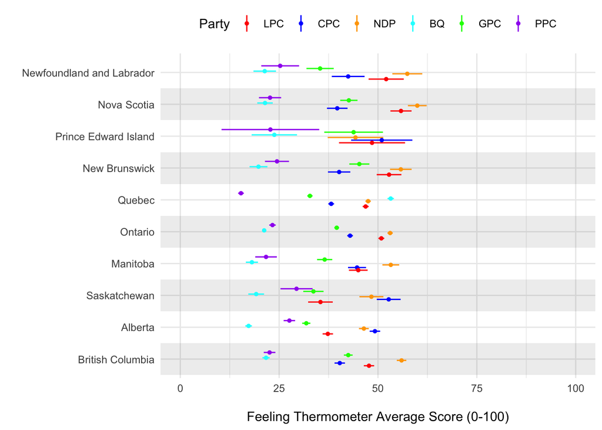

```r
CES |>
  select(UUID,prov,starts_with("pplFeel_")) |>
  select(-pplFeel_Americans,-pplFeel_Francophones) |>
  pivot_longer(c(-UUID,-prov),names_pattern = "pplFeel_(.*)",names_to = "Party", values_to = "score") |>
  group_by(prov,Party) |>
  summarise(ci=mean_cl_normal(score)) |>
  unnest_wider(ci) |>
  mutate(Party=factor(Party,levels=c("LPC","CPC","NDP","BQ","GPC","PPC"))) |>
  ggplot(aes(x=prov,y=y,ymin=ymin,ymax=ymax,color=Party))+
  annotate('rect', xmin = seq(.5,8.5,2), xmax = seq(1.5,9.5,2),
  ymin=-Inf, ymax=Inf, alpha=0.08, fill="black")+
  geom_pointrange(size=0.1,position=position_dodge(0.5)) +
  scale_color_manual(values=c("red","blue","orange","cyan","green","purple"))+
  theme_minimal()+
  theme(legend.position = "top")+
  coord_flip(ylim=c(0,100))+
  labs(x="",y="\nFeeling Thermometer Average Score (0-100)")+
  guides(color = guide_legend(nrow = 1))
```

## 4. Hypothesis Testing

- We know from the Weak Law of Large Numbers that our sample mean converges to the population mean as $n$ increases.
- We know from the Central Limit Theorem that our sampling distribution will be Normal (or Student's t for small samples).
- Setting our null hypothesis as $\mu_0=0$, we know that either:
  $$\bar Y \sim
  N(\mu,\frac{sd_Y}{\sqrt{n}})~~\text{or}~~\bar Y \sim
  t_{n-1}(\mu,\frac{sd_Y}{\sqrt{n}})$$
- Therefore, we can compute $z$ or $t$ scores depending on our sample size:
  $$z=\frac{\bar
  Y-\mu_0}{\sigma}~~\text{or}~~t=\frac{\bar
  Y-\mu_0}{\frac{sd_Y}{\sqrt{n}}}$$
  - Essentially how many standard deviations below or above $\mu_0$ an observation $\bar Y$ is.
  - We use the $z$ or $t$ scores to compute our p-values.

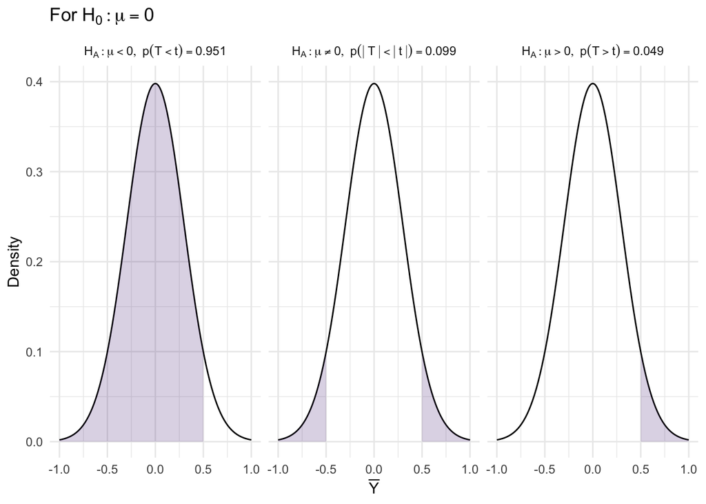

- For **proportion**, we use the $z$ distribution where $se=sd_Y=\sqrt{\frac{p(1-p)}{n}}$.
  - But, we need $np\geq5$ AND $n(1-p)\geq5$ for the normal approximation to work.
  - Where $n$ is the sample size and $p$ is the hypothesized population proportion (our $\mu_0$ from above).
- For **difference of means**:
  - Usually we have $H_0: \mu_0=0$.
  - For two means we have $H_0=\mu_1=\mu_2$ or $H_0=\mu_1-\mu_2=0$, hence:
    - $H_A:\mu_1\neq\mu_2 \rightarrow H_A:\mu_1-\mu_2\neq0$
    - $H_A:\mu_1<\mu_2 \rightarrow H_A:\mu_1-\mu_2<0$
    - $H_A:\mu_1>\mu_2 \rightarrow H_A:\mu_1-\mu_2>0$
  - So, our $z-$ or $t-$statistic: $\frac{Estimate~-~H_0Value}{SE}$, with $SE=\sqrt{\frac{\sigma^2_1}{n_1}+\frac{\sigma^2_2}{n_2}}$.
  - **Paired** t-tests imply that you have the same observations but different variables for both means.
- A few interpretation exercises:
1. Is there a difference in the average score given to the CPC between men and women?

```r
tTest("gender","pplFeel_CPC",data=CES)
```

```
## Summary:
##            mean     n     se
## A man      46.20117 9380  31.91189
## A woman    38.7022  11172 30.65365
## Difference 7.498971 20552 0.438948
##
##
##  Welch Two Sample t-test
##
## data:  pplFeel_CPC by gender
## t = 17.084, df = 19642, p-value < 2.2e-16
## alternative hypothesis: true difference in means between group A man and group A woman is not equal to 0
## 95 percent confidence interval:
##  6.638596 8.359346
## sample estimates:
##   mean in group A man mean in group A woman
##              46.20117              38.70220
```

2. Are liberals ranked higher than conservatives on average?

```r
t.test(CES$pplFeel_LPC,CES$pplFeel_CPC,paired = T,alternative = "greater")
```

```
##
##  Paired t-test
##
## data:  CES$pplFeel_LPC and CES$pplFeel_CPC
## t = 14.114, df = 20459, p-value < 2.2e-16
## alternative hypothesis: true mean difference is greater than 0
## 95 percent confidence interval:
##  4.562733      Inf
## sample estimates:
## mean difference
##        5.164663
```

## 5. Association Tests

| Test | Data type | Why do we use it? | Interpretation |
| --- | --- | --- | --- |
| $\chi^2$ | Nominal | Are the frequencies of the contingency table of the two variables randomly distributed? | $H_0$: Frequencies are randomly distributed. |
| $\phi$ | Nominal (2x2 table) | How strong is the relationship (-1 to 1)? | 0=no >0.1=moderate >0.3=strong |
| Cramer's V | Nominal (>2x2 table) | How strong is the relationship (-1 to 1)? | 0=no >0.1=moderate >0.3=strong |
| $\lambda$ | Nominal | What is the exact improvement in error in predicting DV by knowing IV? | Percent improvement |
| $\gamma$ | Ordinal | How strong is the relationship (-1 to 1)? | 0=no >0.1=moderate >0.3=strong |
| Somer's d | Ordinal | How strong is the relationship (-1 to 1)? (A $\gamma$ that accounts for ties on IV) | 0=no >0.1=moderate >0.3=strong |
| Kendall's $\tau_b$ | Ordinal | How strong is the relationship (-1 to 1)? (A $\gamma$ that accounts for ties on IV and DV) | 0=no >0.1=moderate >0.3=strong |
| Spearman's $\rho_s$ | Ordinal | How strong is the relationship (-1 to 1)? (Talk of a correlation. Testing for monotonic relationship) | 0=no >0.1=moderate >0.3=strong |
| Pearson r | Continuous | How strong is the relationship (-1 to 1)? (Talk of a correlation. Testing for linear relationship) | 0=no >0.1=moderate >0.3=strong |

1. Is there a relationship between `vote` and `pplFeel_Francophones`?

```r
makeStats(CES$vote,CES$pplFeel_Francophones,lambda=T,cramersV=T,chisq=T,gamma=T,d=T,taub=T,rho=T)
```

```
##                       statistic p-value
## Chi-squared           2202.8482       0
## Cramers V                0.1513       0
## Lambda                   0.0551       0
## Kruskal-Goodman Gamma    0.0602       0
## Somers D                 0.0514       0
## Tau-b                    0.0517       0
## Spearmans Rho            0.0707       0
```

2. Is there a linear relationship between `pplFeel_Francophones` and feelings towards the parties?

```r
DAMisc::pwCorrMat(pplFeel_Francophones~pplFeel_LPC+pplFeel_CPC+
                    pplFeel_NDP+pplFeel_BQ+pplFeel_GPC+pplFeel_PPC,data=CES)
```

```
## Pairwise Correlations
##                      pplFeel_Francophones pplFeel_LPC pplFeel_CPC pplFeel_NDP
## pplFeel_Francophones
## pplFeel_LPC          0.162*
## pplFeel_CPC          -0.112*              -0.356*
## pplFeel_NDP          0.108*               0.419*      -0.302*
## pplFeel_BQ           0.398*               0.020*      0.049*      0.068*
## pplFeel_GPC          0.092*               0.278*      -0.165*     0.528*
## pplFeel_PPC          -0.140*              -0.217*     0.302*      -0.134*
##                      pplFeel_BQ pplFeel_GPC pplFeel_PPC
## pplFeel_Francophones
## pplFeel_LPC
## pplFeel_CPC
## pplFeel_NDP
## pplFeel_BQ
## pplFeel_GPC          0.134*
## pplFeel_PPC          0.044*     0.109*
```